# FigureYa149rankHeatmap

# Academic Citation

If you use this code in your work or research, we kindly request that you cite our publication:

Xiaofan Lu, et al. (2025). FigureYa: A Standardized Visualization Framework for Enhancing Biomedical Data Interpretation and Research Efficiency. iMetaMed. https://doi.org/10.1002/imm3.70005

## 需求描述

## Requirement description

分类变量的热图。 Heat map of categorical variables.

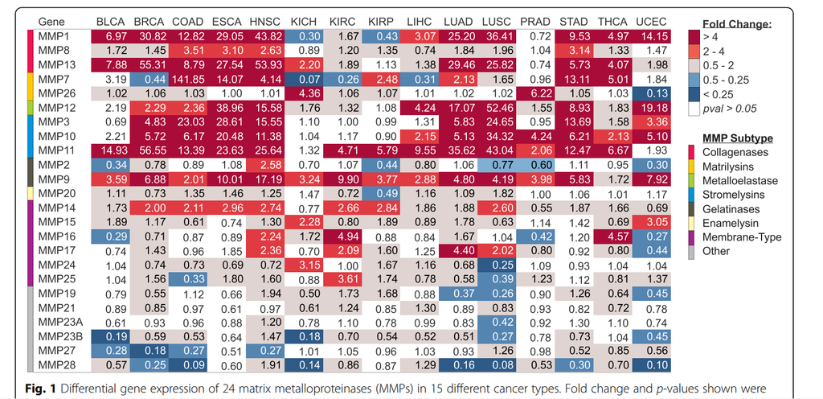

出自https://bmccancer.biomedcentral.com/articles/10.1186/s12885-019-5768-0 From https://bmccancer.biomedcentral.com/articles/10.1186/s12885-019-5768-0

Fig. 1 Differential gene expression of 24 matrix metalloproteinases (MMPs) in 15 different cancer types. Fold change and p-values shown were obtained through comparison of **unmatched control tissue (N between 11 and 114) to tumor tissue** (N between 66 and 1097). Fold change was calculated as the median expression of a gene in tumor divided by the median gene expression in adjacent normal tissue.

**图的解读** **Interpretation of the figure**

- 每行一个基因，每列一个癌症类型
- 颜色分为6档：5档变化倍数（红色上调，蓝色下调）和pvalue不显著（白色）
- 如果pvalue>0.05，无论变化倍数多大都是白色
- 白色和灰色时，字为黑色；蓝色和红色时，字为白色。
- One gene per row, one cancer type per column
- Colors are divided into 6 levels: 5 levels of change fold (red up, blue down) and pvalue not significant (white)
- If pvalue>0.05, it will be white regardless of the change fold
- When it is white and gray, the words are black; when it is blue and red, the words are white.

## 应用场景

## Application scenarios

展示某些基因差异表达结果的时候，经常是把连续性变量当作数值来直接进行热图绘制。也可以像例文那样，先设置成分类变量的，同时用数字来进一步注释。变成分类变量后，可能更清晰的看到趋势 When displaying the results of differential expression of certain genes, continuous variables are often used as numerical values to directly draw heat maps. You can also set it as a categorical variable as in the example text, and use numbers to further annotate it. After becoming a categorical variable, you may see the trend more clearly.

还可以用来转换和展示相关性或其他连续变量。 It can also be used to convert and display correlations or other continuous variables.

这里用complexheatmap画图，其实还可以用pheatmap画图，可参考FigureYa114ternaryCluster，按表达量分为3组（高/低/不变）来画图。 Here we use complexheatmap to draw the picture, but you can also use pheatmap to draw the picture. You can refer to FigureYa114ternaryCluster, which is divided into 3 groups (high/low/unchanged) according to the expression level to draw the picture.

## 环境设置

## Environment settings

```r
source("install_dependencies.R")
```

```
## Starting R package installation...
## ===========================================
##
## Installing Bioconductor packages...
## Package already installed: ComplexHeatmap
##
## ===========================================
## Package installation completed!
## You can now run your R scripts in this directory.
```

Load package

```r
library(ComplexHeatmap)
Sys.setenv(LANGUAGE = "en") #显示英文报错信息
options(stringsAsFactors = FALSE) #禁止chr转成factor
```

## 输入文件

## Input file

- easy_input_logFc.csv，差异表达分析当中的**logFC**值，还可以替换为相关分析的相关系数。
- easy_input_PVal.csv，差异表达分析当中的**P**值。
- genetype.csv，基因的分组，用于画最左侧annotation，非必须。
- easy_input_logFc.csv, **logFC** value in differential expression analysis, can also be replaced by correlation coefficient of correlation analysis.
- easy_input_PVal.csv, **P** value in differential expression analysis.
- genetype.csv, gene grouping, used to draw the leftmost annotation, not required.

```r
logfc <- read.csv("easy_input_logFc.csv", row.names = 1)
logfc[1:2,]
```

```
##           BLCA     BRCA     COAD     ESCA     HNSC       KICH      KIRC
## MMP1  2.786806 5.048694 3.383970 4.096330 5.498597 -2.0245811 0.5215812
## MMP10 1.184887 2.615492 2.447475 4.356999 3.654591 -0.4195746 0.1525066
##             KIRP     LIHC     LUAD     LUSC       PRAD     STAD    THCA
## MMP1  -1.6397127 1.971306 4.776167 4.834148 -0.5065148 3.518468 2.73641
## MMP10 -0.4540304 1.427936 2.591574 4.766261  1.8298976 3.159109 1.80529
##           UCEC
## MMP1  3.738307
## MMP10 2.250303
```

```r
p.val <- read.csv("easy_input_PVal.csv", row.names = 1)
p.val[1:2,]
```

[output not shown]

```r
genetype <- read.csv("genetype.csv")
head(genetype)
```

```
##    gene            type
## 1  MMP1    Collagenases
## 2  MMP8    Collagenases
## 3 MMP13    Collagenases
## 4  MMP7      Matrilysin
## 5 MMP26      Matrilysin
## 6 MMP12 Metalloelastase
```

```r
#为确保热图基因的顺序和分组文件的顺序是一致的
#因此按照基因分组文件里的顺序，对logfc和p.val两个文件排序
#To ensure that the order of heat map genes is consistent with the order of grouping files
#So sort the logfc and p.val files according to the order in the gene grouping file
logfcOrdered <- logfc[genetype$gene,]
p.valOrdered <- p.val[genetype$gene,]
```

## 连续变量转换为分类变量

## Convert continuous variables to categorical variables

分类规则： Classification rules:

- 先按logFC值分成**5类**；
- 如果**pvalue>0.05**，无论倍数多大都作为第6类。
- First divide into **5 categories** according to logFC value;
- If **pvalue>0.05**, it will be regarded as the 6th category regardless of the multiple.

```r
## 对logfc进行分类
## Classify logfc
logfcCat <- apply(logfcOrdered, 2, function(x){
    cut(x, breaks = c(-Inf, -2, -1, 1, 2, Inf),
        labels = c("< -2", "-2 - -1", "-1 - 1", "1 - 2", "> 2"))
})
rownames(logfcCat) <- rownames(logfcOrdered)

## 确保两个数据集的列名和行名顺序一致
## Ensure that the order of column names and row names of the two datasets is consistent
if(!identical(rownames(logfcCat), rownames(p.valOrdered))) p.valOrdered <- p.valOrdered[rownames(logfcCat),]
if(!identical(colnames(logfcCat), colnames(p.valOrdered))) p.valOrdered <- p.valOrdered[colnames(logfcCat)]

## 把P> 0.05的数据标记为 P > 0.05
## Mark data with P> 0.05 as P > 0.05
logfcCat[p.valOrdered >= 0.05] <- "P >= 0.05"
```

## 开始画图

## Start drawing

1. 用转换好的`logfcCat`数据集定义热图的颜色；
2. 在每个热图框中添加数字，由于黑色的数字在深颜色当中不清楚，所以会根据不同的不同的cutoff调整数字的颜色；
3. 添加左侧分类注释；
4. 画图。
5. Define the color of the heat map with the converted `logfcCat` dataset;
6. Add numbers to each heat map frame. Since black numbers are not clear in dark colors, the color of the numbers will be adjusted according to different cutoffs;
7. Add classification annotations on the left;
8. Draw the picture.

### 1. 定义好每个分类变量的颜色

### 1. Define the color of each classification variable

```r
## 查看有多少个分类
## Check how many categories there are
unique(matrix(logfcCat, ncol  = 1))
```

```
##      [,1]
## [1,] "> 2"
## [2,] "1 - 2"
## [3,] "P >= 0.05"
## [4,] "-2 - -1"
## [5,] "-1 - 1"
## [6,] "< -2"
```

```r
## 每个分类定义一个颜色
## Define a color for each category
col_cat <- c("> 2" = "#A80C3A", "1 - 2" = "#ED5E57", "-1 - 1" = "#DDD3D2",
             "-2 - -1" = "#6B9AB7", "< -2" = "#2F5B89", "P >= 0.05" = "white")
```

### 2. 自定义一个字体颜色根据cutoff变化的函数

### 2. Customize a function that changes the font color according to the cutoff

热图颜色为白色和灰色时，字为黑色；蓝色和红色时，字为白色。 When the heat map color is white and gray, the text is black; when it is blue and red, the text is white.

所以我们就定义了一个包含两个数据集的函数 So we define a function that contains two data sets

```r
cell_fun <- function(logfc, dataP, logfcCutoff = 1, PCutoff = 0.05,
                     darkcol = "black", lightcol = "white", digit = 2, fontsize  = 6){
    function(j, i, x, y, width, height, fill){
        if(abs(logfc[i,j]) > logfcCutoff & dataP[i,j] < PCutoff){
            grid.text(round(logfc, digit)[i, j], x, y,
                      gp = gpar(fontsize = fontsize, col  = lightcol))
        }else{
            grid.text(round(logfc, digit)[i, j], x, y,
                      gp = gpar(fontsize = fontsize, col  = darkcol))
        }
    }
}
```

函数的参数包括 The parameters of the function include

- logfc: logfc的数据集
- dataP: P值的数据集
- logfcCutoff和PCutoff的cutoff值
- darkcol和lightcol：浅色和深色的字体颜色
- digit: 热图框当中显示数据的小数点位数
- fontsize: 热图框内字体颜色的大小
- logfc: logfc data set
- dataP: P value data set
- logfcCutoff and PCutoff cutoff values
- darkcol and lightcol: light and dark font colors
- digit: the number of decimal places for displaying data in the heat map box
- fontsize: the size of the font color in the heat map box

### 3. 添加注释

### 3. Add annotations

热图的旁边会有一个对于基因的注释。我们需要对注释信息进行定义 There will be an annotation for the gene next to the heat map. We need to define the annotation information

```r
## 定义注释信息的颜色
## Define the color of the annotation information
an_col <- c("#ED1450", "#FCCA02", "#A7CE35", "#2C92DA", "#59574A", "#FFF8AD", "#A2238E", "#BCBDBF")
names(an_col) <- unique(genetype$type)

## 定义注释信息
## Define the annotation information
row_an <-  HeatmapAnnotation(type = genetype$type, ##注释信息的内容 ##Content of the annotation information
                             show_annotation_name = F, ## 是否显示注释的标题
## Whether to display the title of the annotation
                             col = list(type = an_col), ## 注释信息的颜色
## The color of the annotation information
                             show_legend = T,  ## 是否显示注释信息的说明
 ## Whether to display the description of the annotation
                             annotation_legend_param = list(title = "MMP Subtype"), ## 注释信息图例的标题
## The title of the annotation legend
                             which = "row") #对行或者列进行注释
#Annotate rows or columns
```

### 4. 统一绘图

### 4. Unified drawing

最后我们把所有的数据结合到一起来绘图即可 Finally, we can combine all the data together to draw the picture

```r
pdf("rankHeatmap.pdf", width = 8, height = 4)
Heatmap(matrix = logfcCat,
        name = "logFC", #主要图例的标题 #Title of the main legend
        rect_gp = gpar(col = "NA", lwd = 1), #不画边框，或者用col = "grey"画灰色边框 #No border, or use col = "grey" to draw a gray border
        col = col_cat, #热图颜色 #Heatmap color
        row_names_side = "left",
        cell_fun = cell_fun(logfcOrdered, p.valOrdered),
        row_names_gp = gpar(fontsize = 8), #基因名字号 #Gene name
        column_names_gp = gpar(fontsize = 8), #肿瘤类型字号 #Tumor type font size
        column_names_rot = 45, #肿瘤类型呈45度 #Tumor type at 45 degrees
        left_annotation = row_an) #左侧基因分类，如果不画，就筛掉这个参数 #Left gene classification, if not drawn, this parameter will be filtered out
dev.off()
```

[figure not shown]